# STAT 413/613

Richard Ressler

2020-04-05

# 1 Learning Outcomes

- Manipulate (nested) data frames using `nest()` and `unest()`
- Apply the construct of List Columns in R
- Use the broom package to facilitate working with models
- Manipulate data to develop, test, and plot many models at once
- References: Chapter 25 from [RDS](https://r4ds.had.co.nz/).

# 2 The Gapminder Data Sets

- [Gapminder Foundation](https://en.wikipedia.org/wiki/Gapminder_Foundation)
- [Hans Rosling Video with Gapminder data](https://www.youtube.com/watch?v=jbkSRLYSojo.)
- The gapminder package has a curated subset of [Gapminder data](https://www.gapminder.org/data/)

# 3 Motivation: A Life Expectancy Example

- Load the gapminder package and data. Install the package if needed.

  ```r
  library(tidyverse)
  library(broom)
  library(gapminder)
  data("gapminder")
  glimpse(gapminder)
  ```

  ```
  ## Observations: 1,704
  ## Variables: 6
  ## $ country   <fct> Afghanistan, Afghanistan, Afghanistan, Afghanistan, Afghani…
  ## $ continent <fct> Asia, Asia, Asia, Asia, Asia, Asia, Asia, Asia, Asia, Asia,…
  ## $ year      <int> 1952, 1957, 1962, 1967, 1972, 1977, 1982, 1987, 1992, 1997,…
  ## $ lifeExp   <dbl> 28.801, 30.332, 31.997, 34.020, 36.088, 38.438, 39.854, 40.…
  ## $ pop       <int> 8425333, 9240934, 10267083, 11537966, 13079460, 14880372, 1…
  ## $ gdpPercap <dbl> 779.4453, 820.8530, 853.1007, 836.1971, 739.9811, 786.1134,…
  ```

- Suppose we want to look at how life expectancy has changed over time in each country/continent:

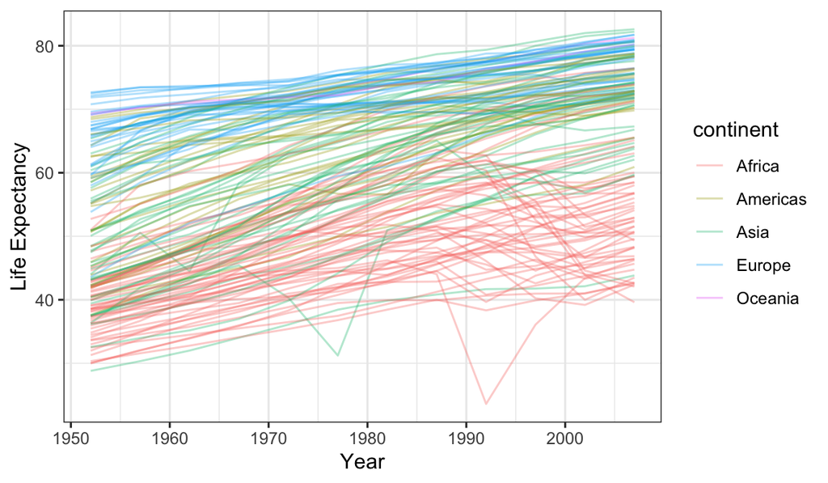

  ```r
  gapminder %>%
    ggplot(aes(x = year, y = lifeExp, group = country, color = continent)) +
    geom_line(alpha = 1/3) +
    xlab("Year") +
    ylab("Life Expectancy")
  ```

- General trend is going up but some countries look quite different.
- We can compare by modeling the trend
- We can do this for a country using a linear regression model:

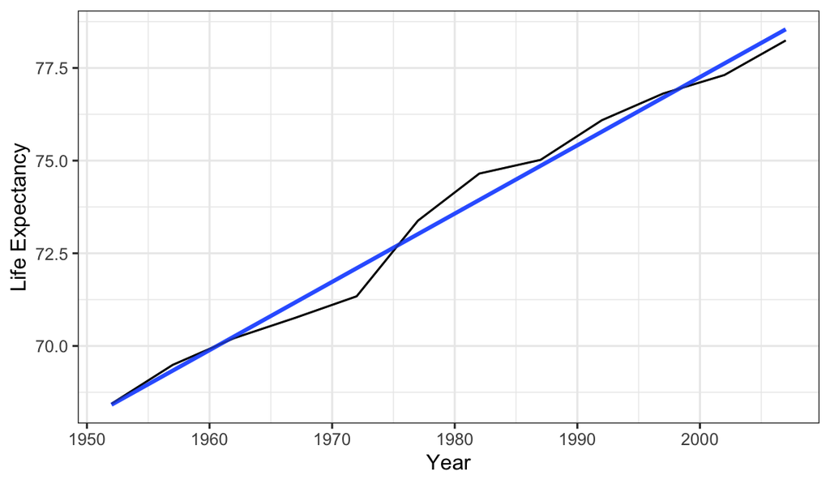

  ```r
  gapminder %>%
    filter(country == "United States") ->
    usdf

  ggplot(usdf, aes(x = year, y = lifeExp)) +
    geom_line() +
    geom_smooth(method = "lm", se = FALSE) +
    geom_line(alpha = 1/3) +
    xlab("Year") +
    ylab("Life Expectancy")
  ```

  ```r
  us_lmout <- lm(lifeExp ~ year, data = usdf)
  tidy_uslm <- tidy(us_lmout)
  tidy_uslm
  ```

  ```
  ## # A tibble: 2 x 5
  ##   term        estimate std.error statistic  p.value
  ##   <chr>          <dbl>     <dbl>     <dbl>    <dbl>
  ## 1 (Intercept) -291.     13.8         -21.1 1.25e- 9
  ## 2 year           0.184   0.00696      26.5 1.37e-10
  ```

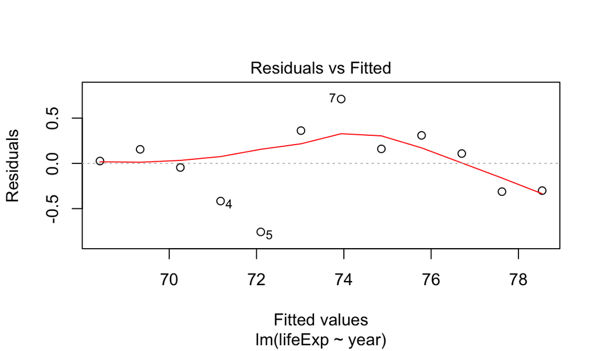

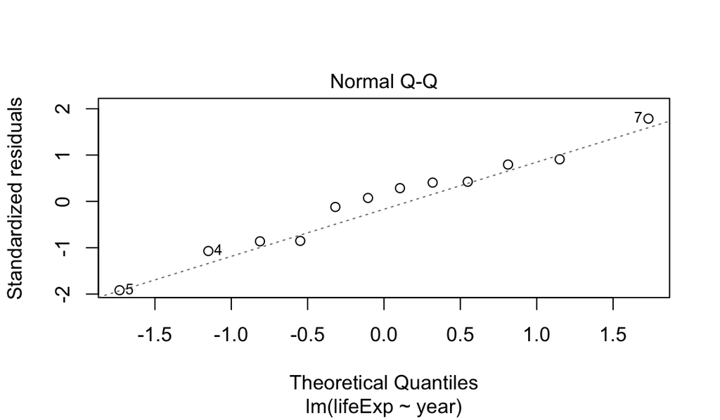

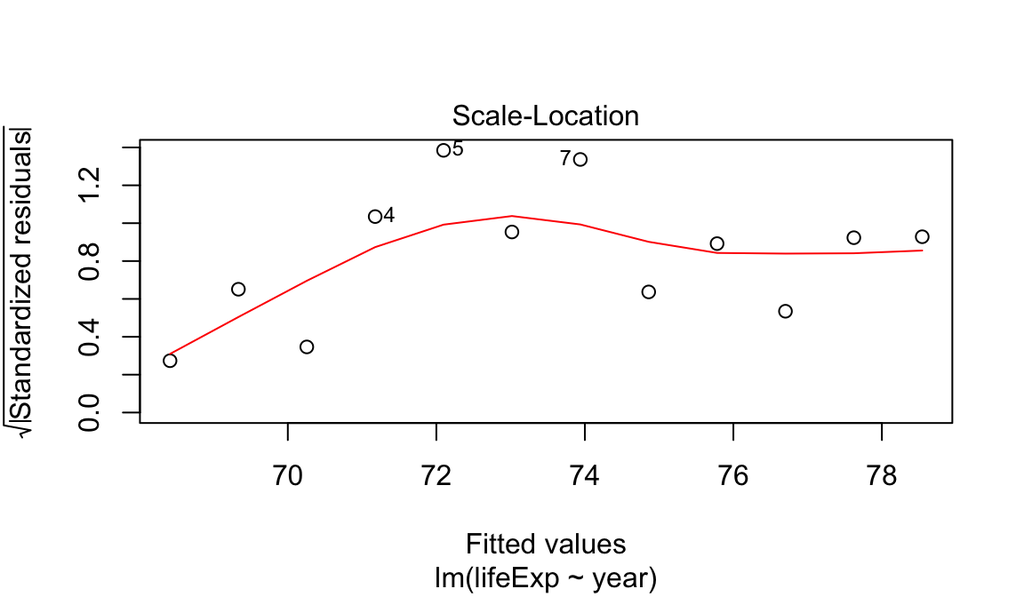

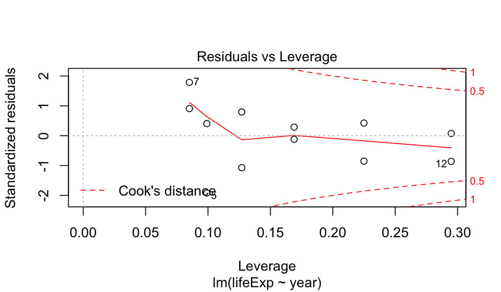

  ```r
  plot(us_lmout)
  ```

  ```r
  # The residuals don't look too bad but there seems to be some non-linearity
  ```

- So each year, the US has been increasing its life expectancy by 0.1841692 years.
- How can we get these coefficient estimates for each of the 142 countries?
  - We could use a function inside a for loop, but there is an easier way we’ll see in a few minutes

# 4 A Second Example: National Populations over time

- Given the skewness of the population data, let’s log the `pop` variable at base 2

  ```r
  gapminder %>%
    mutate(logpop = log2(pop)) ->
    gapminder
  ```

- **Exercise**: Create a line plot for year vs log-population for each country/continent.
- **Exercise**: For China, fit a linear model for log-population on year.
  - Check if the assumptions of the linear model are fulfilled.
  - Interpret the coefficients

# 5 Creating a Nested Data Frame using `nest()`

- Now we want to get the linear model for every country.
- We know we can use `purrr:map*()` to apply a function to each row of a column in a data frame
- Here though, we want to operate on the subsets of rows belonging to each country where it is not clear every country has the same number of rows.
- Solution: Use a data structure new to us: the **nested data frame**.
- To create a nested data frame, start with a grouped data frame, and “nest” it
  - we use `group_by()` to identify the elements we want to group in our data frame
- The `nest()` function from the tidyr package will turn a *grouped* data frame into a data frame where each group is a row.
- All of the observations for each grouping are placed in the `data` variable as a data frame.
- Let’s look at an example.

  ```r
  gapminder %>%
    group_by(country, continent) %>%
    nest() ->
    nested_gap_df

  nested_gap_df # one row per country
  ```

  ```
  ## # A tibble: 142 x 3
  ## # Groups:   country, continent [710]
  ##    country     continent data
  ##    <fct>       <fct>     <list>
  ##  1 Afghanistan Asia      <tibble [12 × 5]>
  ##  2 Albania     Europe    <tibble [12 × 5]>
  ##  3 Algeria     Africa    <tibble [12 × 5]>
  ##  4 Angola      Africa    <tibble [12 × 5]>
  ##  5 Argentina   Americas  <tibble [12 × 5]>
  ##  6 Australia   Oceania   <tibble [12 × 5]>
  ##  7 Austria     Europe    <tibble [12 × 5]>
  ##  8 Bahrain     Asia      <tibble [12 × 5]>
  ##  9 Bangladesh  Asia      <tibble [12 × 5]>
  ## 10 Belgium     Europe    <tibble [12 × 5]>
  ## # … with 132 more rows
  ```

- Note: The `data` variable is a list so `data` is known as a **list column** of the `nested_gap_df` data frame.
  - Each element in this list column is a data frame with all of the observations in the group we created by `group_by(country, continent)`.
- We can think of each row as having two elements of meta-data (country and continent) and then the data frame for that meta-data.
- Note the variables in the data variable data frames do Not include `country` and `continent`
- Observations from Afghanistan

  ```r
  nested_gap_df$data[[1]]
  ```

  ```
  ## # A tibble: 12 x 5
  ##     year lifeExp      pop gdpPercap logpop
  ##    <int>   <dbl>    <int>     <dbl>  <dbl>
  ##  1  1952    28.8  8425333      779.   23.0
  ##  2  1957    30.3  9240934      821.   23.1
  ##  3  1962    32.0 10267083      853.   23.3
  ##  4  1967    34.0 11537966      836.   23.5
  ##  5  1972    36.1 13079460      740.   23.6
  ##  6  1977    38.4 14880372      786.   23.8
  ##  7  1982    39.9 12881816      978.   23.6
  ##  8  1987    40.8 13867957      852.   23.7
  ##  9  1992    41.7 16317921      649.   24.0
  ## 10  1997    41.8 22227415      635.   24.4
  ## 11  2002    42.1 25268405      727.   24.6
  ## 12  2007    43.8 31889923      975.   24.9
  ```

- Observations from Albania

  ```r
  nested_gap_df$data[[2]]
  ```

  ```
  ## # A tibble: 12 x 5
  ##     year lifeExp     pop gdpPercap logpop
  ##    <int>   <dbl>   <int>     <dbl>  <dbl>
  ##  1  1952    55.2 1282697     1601.   20.3
  ##  2  1957    59.3 1476505     1942.   20.5
  ##  3  1962    64.8 1728137     2313.   20.7
  ##  4  1967    66.2 1984060     2760.   20.9
  ##  5  1972    67.7 2263554     3313.   21.1
  ##  6  1977    68.9 2509048     3533.   21.3
  ##  7  1982    70.4 2780097     3631.   21.4
  ##  8  1987    72   3075321     3739.   21.6
  ##  9  1992    71.6 3326498     2497.   21.7
  ## 10  1997    73.0 3428038     3193.   21.7
  ## 11  2002    75.7 3508512     4604.   21.7
  ## 12  2007    76.4 3600523     5937.   21.8
  ```

  ```r
  str(nested_gap_df[[24,3]])
  ```

  ```
  ## Classes 'tbl_df', 'tbl' and 'data.frame':    12 obs. of  5 variables:
  ##  $ year     : int  1952 1957 1962 1967 1972 1977 1982 1987 1992 1997 ...
  ##  $ lifeExp  : num  54.7 56.1 57.9 60.5 63.4 ...
  ##  $ pop      : int  6377619 7048426 7961258 8858908 9717524 10599793 11487112 12463354 13572994 14599929 ...
  ##  $ gdpPercap: num  3940 4316 4519 5107 5494 ...
  ##  $ logpop   : num  22.6 22.7 22.9 23.1 23.2 ...
  ```

- Notice that I need to use double brackets to extract the elements of `data` as a data frame because `data` is a list.
- **Exercise**: Use `which()` to extract the United States data frame from `nested_gap_df`. This code should be *general* so the row location of the US in the data frame does not matter.

# 6 Fit many models with a Nested data frame using `map()`

- We can now use purrr to fit a model on all of the elements (rows) of `data` since the elements (rows) are data frames.

  ```r
  nested_gap_df %>%
    mutate(lmout = map(data, ~lm(lifeExp ~ year, data = .))) ->
    nested_gap_df
  ```

- Recall: the `data = .` argument means use all of the elements from the first `map()` argument, the`data` column in the `nested_gap_df` data frame, as value for the `lm()` `data =` argument.
- Let’s look at the results with our new column `lmout`
  - It is also a *list column* where the elements of the list are of class `lm`

    ```r
    nested_gap_df
    ```

    ```
    ## # A tibble: 142 x 4
    ## # Groups:   country, continent [710]
    ##    country     continent data              lmout
    ##    <fct>       <fct>     <list>            <list>
    ##  1 Afghanistan Asia      <tibble [12 × 5]> <lm>
    ##  2 Albania     Europe    <tibble [12 × 5]> <lm>
    ##  3 Algeria     Africa    <tibble [12 × 5]> <lm>
    ##  4 Angola      Africa    <tibble [12 × 5]> <lm>
    ##  5 Argentina   Americas  <tibble [12 × 5]> <lm>
    ##  6 Australia   Oceania   <tibble [12 × 5]> <lm>
    ##  7 Austria     Europe    <tibble [12 × 5]> <lm>
    ##  8 Bahrain     Asia      <tibble [12 × 5]> <lm>
    ##  9 Bangladesh  Asia      <tibble [12 × 5]> <lm>
    ## 10 Belgium     Europe    <tibble [12 × 5]> <lm>
    ## # … with 132 more rows
    ```

    ```r
    class(nested_gap_df$lmout[[1]])
    ```

    ```
    ## [1] "lm"
    ```

- Each element of the `lmout` column is the model output object from fitting `lm()` to each row’s data frame in the `data` column.

  ```r
  ## Afghanistan fit
  nested_gap_df$lmout[[1]]
  ```

  ```
  ##
  ## Call:
  ## lm(formula = lifeExp ~ year, data = .)
  ##
  ## Coefficients:
  ## (Intercept)         year
  ##   -507.5343       0.2753
  ```

  ```r
  ## Albania fit
     summary(nested_gap_df$lmout[[2]])
  ```

  ```
  ##
  ## Call:
  ## lm(formula = lifeExp ~ year, data = .)
  ##
  ## Residuals:
  ##     Min      1Q  Median      3Q     Max
  ## -3.9991 -1.2452  0.3723  1.4421  2.2440
  ##
  ## Coefficients:
  ##               Estimate Std. Error t value Pr(>|t|)
  ## (Intercept) -594.07251   65.65536  -9.048 3.94e-06 ***
  ## year           0.33468    0.03317  10.091 1.46e-06 ***
  ## ---
  ## Signif. codes:  0 '***' 0.001 '**' 0.01 '*' 0.05 '.' 0.1 ' ' 1
  ##
  ## Residual standard error: 1.983 on 10 degrees of freedom
  ## Multiple R-squared:  0.9106, Adjusted R-squared:  0.9016
  ## F-statistic: 101.8 on 1 and 10 DF,  p-value: 1.463e-06
  ```

- **Exercise**: For each country, fit a linear model of log-population on year. Save this fit as the `lmpop` column in `nested_gap_df`.

# 7 Get Model Summaries and data using Broom package functions: `tidy()`, `glance()`, and `augment()`

- We can also use `map()` to create list columns of model summaries using generic functions from the broom package: `tidy()`, `augment()`, and `glance()`.
- The `tidy()` function summarizes a model’s statistical findings such as coefficients of a regression

  ```r
  tidy(us_lmout, conf.int = TRUE)
  ```

  ```
  ## # A tibble: 2 x 7
  ##   term        estimate std.error statistic  p.value conf.low conf.high
  ##   <chr>          <dbl>     <dbl>     <dbl>    <dbl>    <dbl>     <dbl>
  ## 1 (Intercept) -291.     13.8         -21.1 1.25e- 9 -322.     -260.
  ## 2 year           0.184   0.00696      26.5 1.37e-10    0.169     0.200
  ```

- The `glance()` function provides a one-row summary of model-level statistics.

  ```r
  glance(us_lmout)
  ```

  ```
  ## # A tibble: 1 x 11
  ##   r.squared adj.r.squared sigma statistic  p.value    df logLik   AIC   BIC
  ##       <dbl>         <dbl> <dbl>     <dbl>    <dbl> <int>  <dbl> <dbl> <dbl>
  ## 1     0.986         0.985 0.416      700. 1.37e-10     2  -5.41  16.8  18.3
  ## # … with 2 more variables: deviance <dbl>, df.residual <int>
  ```

- The `augment()` function adds model data, fitted and residual values, as well as other values to a data frame

  ```r
  head(augment(us_lmout),3)
  ```

  ```
  ## # A tibble: 3 x 9
  ##   lifeExp  year .fitted .se.fit  .resid  .hat .sigma .cooksd .std.resid
  ##     <dbl> <int>   <dbl>   <dbl>   <dbl> <dbl>  <dbl>   <dbl>      <dbl>
  ## 1    68.4  1952    68.4   0.226  0.0262 0.295  0.439 0.00117     0.0748
  ## 2    69.5  1957    69.3   0.197  0.155  0.225  0.435 0.0261      0.424
  ## 3    70.2  1962    70.3   0.171 -0.0455 0.169  0.438 0.00147    -0.120
  ```

  ```r
  nested_gap_df %>%
    mutate(tidyout = map(lmout, ~tidy(., conf.int = TRUE)),
           augmentout = map(lmout, augment),
           glanceout = map(lmout, glance)) ->
    nested_gap_df
  nested_gap_df
  ```

  ```
  ## # A tibble: 142 x 7
  ## # Groups:   country, continent [710]
  ##    country   continent data        lmout  tidyout     augmentout    glanceout
  ##    <fct>     <fct>     <list>      <list> <list>      <list>        <list>
  ##  1 Afghanis… Asia      <tibble [1… <lm>   <tibble [2… <tibble [12 … <tibble [1 …
  ##  2 Albania   Europe    <tibble [1… <lm>   <tibble [2… <tibble [12 … <tibble [1 …
  ##  3 Algeria   Africa    <tibble [1… <lm>   <tibble [2… <tibble [12 … <tibble [1 …
  ##  4 Angola    Africa    <tibble [1… <lm>   <tibble [2… <tibble [12 … <tibble [1 …
  ##  5 Argentina Americas  <tibble [1… <lm>   <tibble [2… <tibble [12 … <tibble [1 …
  ##  6 Australia Oceania   <tibble [1… <lm>   <tibble [2… <tibble [12 … <tibble [1 …
  ##  7 Austria   Europe    <tibble [1… <lm>   <tibble [2… <tibble [12 … <tibble [1 …
  ##  8 Bahrain   Asia      <tibble [1… <lm>   <tibble [2… <tibble [12 … <tibble [1 …
  ##  9 Banglade… Asia      <tibble [1… <lm>   <tibble [2… <tibble [12 … <tibble [1 …
  ## 10 Belgium   Europe    <tibble [1… <lm>   <tibble [2… <tibble [12 … <tibble [1 …
  ## # … with 132 more rows
  ```

- We now have model summaries within all groups and all captured in the same data frame
- That is a major benefit to using List Columns - you can keep all the data in once place so you can operate at the meta-data level
  - e.g., if you want to filter by continent it is easy to do so.

    ```r
    nested_gap_df %>%
      filter(continent =="Asia") %>%
    head()
    ```

    ```
    ## # A tibble: 6 x 7
    ## # Groups:   country, continent [6]
    ##   country     continent data        lmout  tidyout    augmentout    glanceout
    ##   <fct>       <fct>     <list>      <list> <list>     <list>        <list>
    ## 1 Afghanistan Asia      <tibble [1… <lm>   <tibble [… <tibble [12 … <tibble [1 …
    ## 2 Bahrain     Asia      <tibble [1… <lm>   <tibble [… <tibble [12 … <tibble [1 …
    ## 3 Bangladesh  Asia      <tibble [1… <lm>   <tibble [… <tibble [12 … <tibble [1 …
    ## 4 Cambodia    Asia      <tibble [1… <lm>   <tibble [… <tibble [12 … <tibble [1 …
    ## 5 China       Asia      <tibble [1… <lm>   <tibble [… <tibble [12 … <tibble [1 …
    ## 6 Hong Kong,… Asia      <tibble [1… <lm>   <tibble [… <tibble [12 … <tibble [1 …
    ```

- We can look at individual summaries as before
  - Afghanistan summary

  ```r
  nested_gap_df$tidyout[[1]]
  ```

  ```
  ## # A tibble: 2 x 7
  ##   term        estimate std.error statistic      p.value conf.low conf.high
  ##   <chr>          <dbl>     <dbl>     <dbl>        <dbl>    <dbl>     <dbl>
  ## 1 (Intercept) -508.      40.5        -12.5 0.000000193  -598.     -417.
  ## 2 year           0.275    0.0205      13.5 0.0000000984    0.230     0.321
  ```

  - Albania summary

    ```r
    nested_gap_df$tidyout[[2]]
    ```

    ```
    ## # A tibble: 2 x 7
    ##   term        estimate std.error statistic    p.value conf.low conf.high
    ##   <chr>          <dbl>     <dbl>     <dbl>      <dbl>    <dbl>     <dbl>
    ## 1 (Intercept) -594.      65.7        -9.05 0.00000394 -740.     -448.
    ## 2 year           0.335    0.0332     10.1  0.00000146    0.261     0.409
    ```

- **Exercise**: Use `tidy()` to get model summaries of your linear model fits of log-population on year.
  - Add these summaries as another column in `nested_gap_df`.
  - Compare the results for China to the results from china_lm

# 8 Extract All the Data from One List Column into the data frame using `unnest()`

- Using the `unnest()` function, followed by the `ungroup()` function, will convert a single list column into a new data frame with the meta-data, the still-nested list columns, AND, all the elements of the unnested column as variables and rows.

  ```r
  unnest(nested_gap_df, tidyout) %>%
    ungroup() ->
    model_summary_df

  model_summary_df
  ```

  ```
  ## # A tibble: 284 x 13
  ##    country continent data  lmout term  estimate std.error statistic  p.value
  ##    <fct>   <fct>     <lis> <lis> <chr>    <dbl>     <dbl>     <dbl>    <dbl>
  ##  1 Afghan… Asia      <tib… <lm>  (Int… -5.08e+2  40.5        -12.5  1.93e- 7
  ##  2 Afghan… Asia      <tib… <lm>  year   2.75e-1   0.0205      13.5  9.84e- 8
  ##  3 Albania Europe    <tib… <lm>  (Int… -5.94e+2  65.7         -9.05 3.94e- 6
  ##  4 Albania Europe    <tib… <lm>  year   3.35e-1   0.0332      10.1  1.46e- 6
  ##  5 Algeria Africa    <tib… <lm>  (Int… -1.07e+3  43.8        -24.4  3.07e-10
  ##  6 Algeria Africa    <tib… <lm>  year   5.69e-1   0.0221      25.7  1.81e-10
  ##  7 Angola  Africa    <tib… <lm>  (Int… -3.77e+2  46.6         -8.08 1.08e- 5
  ##  8 Angola  Africa    <tib… <lm>  year   2.09e-1   0.0235       8.90 4.59e- 6
  ##  9 Argent… Americas  <tib… <lm>  (Int… -3.90e+2   9.68       -40.3  2.14e-12
  ## 10 Argent… Americas  <tib… <lm>  year   2.32e-1   0.00489     47.4  4.22e-13
  ## # … with 274 more rows, and 4 more variables: conf.low <dbl>, conf.high <dbl>,
  ## #   augmentout <list>, glanceout <list>
  ```

- Note 142 countries and two elements the tidy summaries means 284 rows in the unnested data frame
- You do this so you can plot some cool things.

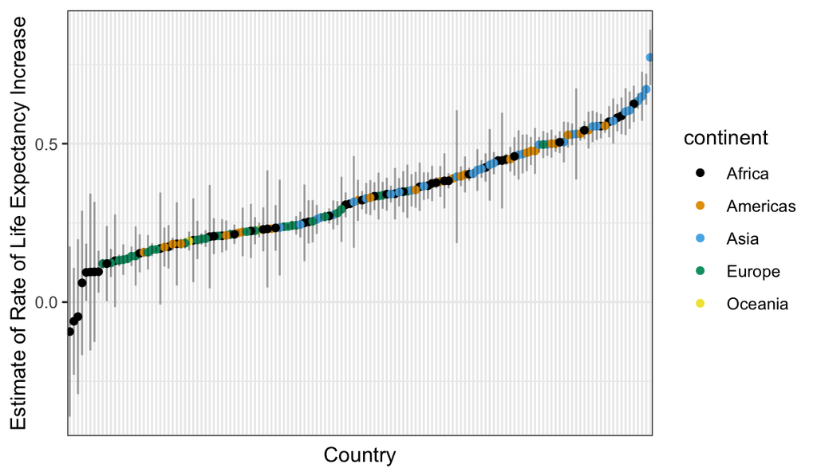

  ```r
  library(ggthemes)
  model_summary_df %>%
    filter(term == "year") %>%
    mutate(country = fct_reorder(country, estimate)) %>%
    ggplot(aes(x = country, y = estimate, color = continent)) +
    geom_point() +
    geom_segment(aes(x = country, xend = country, y = conf.low, yend = conf.high),
                 color = "black",
                 alpha = 1/3) +
    ylab("Estimate of Rate of Life Expectancy Increase") +
    xlab("Country") +
    theme(axis.text.x = element_blank(),
          axis.ticks.x = element_blank()) +
    scale_color_colorblind()
  ```

- You can check all of the models’ qualities by looking at the residuals

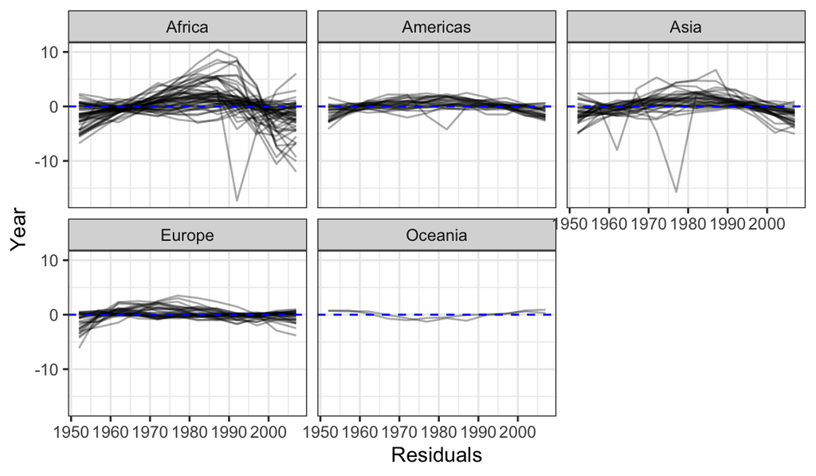

  ```r
  unnest(nested_gap_df, augmentout) ->
    augment_df

  augment_df %>%
    ggplot(aes(x = year, y = .resid, group = country)) +
    geom_line(alpha = 1/3) +
    facet_wrap(.~continent) +
    geom_hline(yintercept = 0, lty = 2, col = "blue") +
    xlab("Residuals") +
    ylab("Year")
  ```

- Above, we see there is a lot of curvature we are not accounting for.
- **Exercise**: Unnest the `tidy()` output from the linear model fit of log-population on year.
  - Which countries have seen the greatest increase in population?
  - Have any seen a decline?

## 8.1 Unnest into a Regular Data frame using `select()`

- If you don’t want to keep all the list columns in a new data frame select only the columns you want plus the column you want to unnest.

  ```r
  head(nested_gap_df)
  ```

  ```
  ## # A tibble: 6 x 7
  ## # Groups:   country, continent [710]
  ##   country   continent data        lmout  tidyout      augmentout    glanceout
  ##   <fct>     <fct>     <list>      <list> <list>       <list>        <list>
  ## 1 Afghanis… Asia      <tibble [1… <lm>   <tibble [2 … <tibble [12 … <tibble [1 …
  ## 2 Albania   Europe    <tibble [1… <lm>   <tibble [2 … <tibble [12 … <tibble [1 …
  ## 3 Algeria   Africa    <tibble [1… <lm>   <tibble [2 … <tibble [12 … <tibble [1 …
  ## 4 Angola    Africa    <tibble [1… <lm>   <tibble [2 … <tibble [12 … <tibble [1 …
  ## 5 Argentina Americas  <tibble [1… <lm>   <tibble [2 … <tibble [12 … <tibble [1 …
  ## 6 Australia Oceania   <tibble [1… <lm>   <tibble [2 … <tibble [12 … <tibble [1 …
  ```

  ```r
  nested_gap_df  %>%
      select(country, continent, glanceout) %>%
      unnest(glanceout) %>%
      ungroup() ->
      df_glance
  head(df_glance)
  ```

  ```
  ## # A tibble: 6 x 13
  ##   country continent r.squared adj.r.squared sigma statistic  p.value    df
  ##   <fct>   <fct>         <dbl>         <dbl> <dbl>     <dbl>    <dbl> <int>
  ## 1 Afghan… Asia          0.948         0.942 1.22      181.  9.84e- 8     2
  ## 2 Albania Europe        0.911         0.902 1.98      102.  1.46e- 6     2
  ## 3 Algeria Africa        0.985         0.984 1.32      662.  1.81e-10     2
  ## 4 Angola  Africa        0.888         0.877 1.41       79.1 4.59e- 6     2
  ## 5 Argent… Americas      0.996         0.995 0.292    2246.  4.22e-13     2
  ## 6 Austra… Oceania       0.980         0.978 0.621     481.  8.67e-10     2
  ## # … with 5 more variables: logLik <dbl>, AIC <dbl>, BIC <dbl>, deviance <dbl>,
  ## #   df.residual <int>
  ```

- now we can look at the models that did not fit well

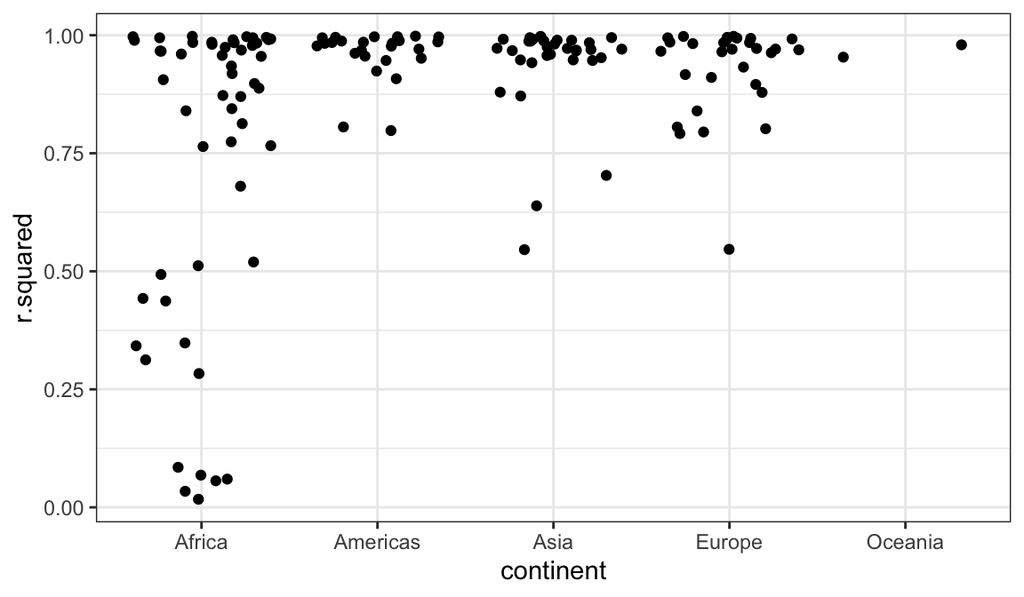

  ```r
  df_glance %>%
    ggplot(aes(x = continent, y = r.squared)) +
    geom_jitter()
  ```

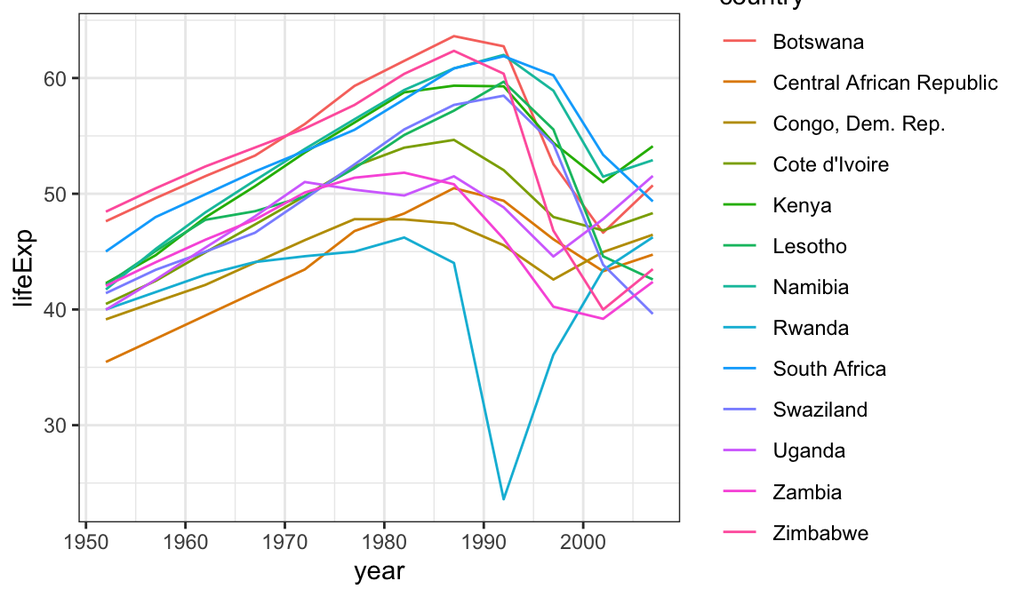

  ```r
  bad_fit <- filter(df_glance, r.squared < 0.5)

  gapminder %>%
    semi_join(bad_fit, by = "country") %>%
    ggplot(aes(year, lifeExp, colour = country)) +
    geom_line()
  ```

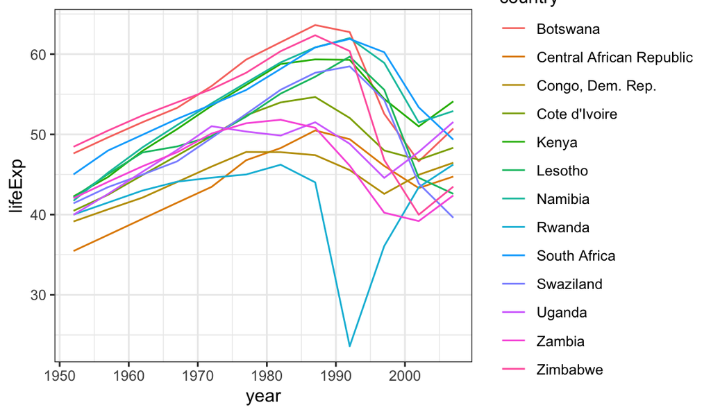

  ```r
  # Rwandan Civil War 1990- 1994
  # Effects of HIV and related increases in child mortality
  # Botswana had the second highest infection rate in the world at one point
  # https://en.wikipedia.org/wiki/List_of_countries_by_HIV/AIDS_adult_prevalence_rate

  gapminder %>%
    semi_join(bad_fit, by = "country") %>%
    ggplot(aes(year, lifeExp, colour = country)) +
      geom_line()
  ```

# 9 `mtcars` exercise

Recall we used the `split()` function on the `mtcars` dataset to get the regression coefficient estimates of a regression of `mpg` on `wt`.

```r
data("mtcars")
mtcars %>%
  split(.$cyl) %>%
  map(~lm(mpg ~ wt, data = .)) %>%
  map(~tidy(.)) %>%
  map_dbl(~.$estimate[2])
```

```
##         4         6         8
## -5.647025 -2.780106 -2.192438
```

Redo this exercise using the `nest()`-`map()`-`unnest()` workflow we just went through.

# 10 Other Uses of List Columns

- We’ve seen how list columns can capture output from models to keep with meta-data
- We can also generate list columns that are useful in other ways:
  - Output from `str_extra_all()` or `str_split()` used inside a `mutate()`
  - Output from `quantile()` with `summarise()`

    ```r
    probs <- c(0.01, 0.25, 0.5, 0.75, 0.99)
    mtcars %>%
      group_by(cyl) %>%
      summarise(p = list(probs), q = list(quantile(mpg, probs))) %>%
      unnest(cols = c(p,q))
    ```

    ```
    ## # A tibble: 15 x 3
    ##      cyl     p     q
    ##    <dbl> <dbl> <dbl>
    ##  1     4  0.01  21.4
    ##  2     4  0.25  22.8
    ##  3     4  0.5   26
    ##  4     4  0.75  30.4
    ##  5     4  0.99  33.8
    ##  6     6  0.01  17.8
    ##  7     6  0.25  18.6
    ##  8     6  0.5   19.7
    ##  9     6  0.75  21
    ## 10     6  0.99  21.4
    ## 11     8  0.01  10.4
    ## 12     8  0.25  14.4
    ## 13     8  0.5   15.2
    ## 14     8  0.75  16.2
    ## 15     8  0.99  19.1
    ```

- Note: if you only want a single value out of a list column element you can also just use one of the `map*()` functions inside of a `mutate()` instead of `unnest()` which returns all of the original values.